# Repeated Measures

Neil Stewart

```r
library(tidyverse)
library(gridExtra)
library(emmeans) # for emmeans() and contrast()
options(width=100)
```

# Objectives

- Understand the analysis of repeated measures data
- Understand the difference between *null hypothesis significance testing* (NHST) and *estimation*
- Be able to run repeated measures analysis in R:
  - Using `aov` and `summary`, for the NHST approach
  - Using `emmeans`, for the estimation approach
- Be able to report results in plain English using a NHST or estimation approach
- Be able to produce excellent plots with `ggplot`

# Reading

Howell (2017) Chapters 13 and 18 are an excellent introduction to repeated measures

# A workplace well-being intervention

We measured workers’ well-being every week for five weeks. Between weeks 2 and 3, we make a workplace intervention intended to increase well-being

```r
intervention <- read_csv("well-being.csv")
intervention <- intervention %>% mutate(time=as.factor(time))
intervention <- arrange(intervention, sub, time)
intervention
```

```
## # A tibble: 40 x 4
##    sub   sex   time  well.being
##    <chr> <chr> <fct>      <int>
##  1 s1    Male  1              6
##  2 s1    Male  2              6
##  3 s1    Male  3              8
##  4 s1    Male  4              8
##  5 s1    Male  5              8
##  6 s2    Male  1              4
##  7 s2    Male  2              5
##  8 s2    Male  3              6
##  9 s2    Male  4              7
## 10 s2    Male  5              7
## # ... with 30 more rows
```

# The incorrect ANOVA

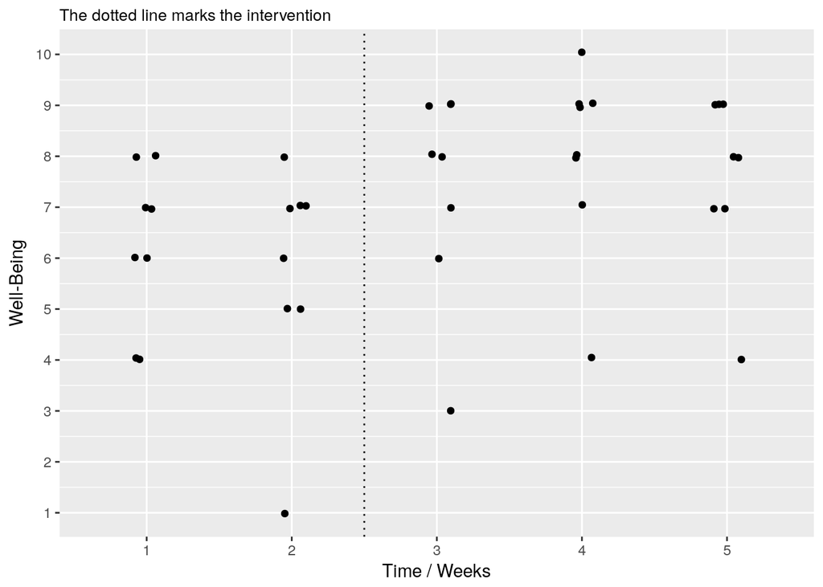

```r
ggplot(intervention, aes(x=time, y=well.being)) + geom_jitter(height=0.05, width=0.1) + scale_y_continuous(breaks=1:10) + labs(x="Time / Weeks", y="Well-Being", subtitle="The dotted line marks the intervention") + geom_vline(xintercept=2.5, lty=3)
```

```r
m.incorrect <- lm(well.being~time, data=intervention)
summary(m.incorrect)
```

```
##
## Call:
## lm(formula = well.being ~ time, data = intervention)
##
## Residuals:
##     Min      1Q  Median      3Q     Max
## -4.7500 -0.6562  0.5000  1.2813  2.2500
##
## Coefficients:
##             Estimate Std. Error t value Pr(>|t|)
## (Intercept)   6.2500     0.6675   9.364  4.6e-11 ***
## time2        -0.5000     0.9440  -0.530   0.5997
## time3         1.1250     0.9440   1.192   0.2414
## time4         1.7500     0.9440   1.854   0.0722 .
## time5         1.3750     0.9440   1.457   0.1541
## ---
## Signif. codes:  0 '***' 0.001 '**' 0.01 '*' 0.05 '.' 0.1 ' ' 1
##
## Residual standard error: 1.888 on 35 degrees of freedom
## Multiple R-squared:  0.1899, Adjusted R-squared:  0.09736
## F-statistic: 2.052 on 4 and 35 DF,  p-value: 0.1084
```

```r
anova(m.incorrect)
```

```
## Analysis of Variance Table
##
## Response: well.being
##           Df Sum Sq Mean Sq F value Pr(>F)
## time       4  29.25  7.3125  2.0516 0.1084
## Residuals 35 124.75  3.5643
```

According to this *incorrect* ANOVA, there is no significant effect of time, $F(4,35)=2.1$, $p=.11$.

## Contrasts (on the incorrect model)

We can hand-build some custom contrasts

`after.minus.before` compares the average of times 1 and 2 with the average of times 3, 4, and 5

`t3.minus.t2` compares times 2 and 3

```r
(  m.incorrect.emm <- emmeans(m.incorrect, ~time)  )
```

```
##  time emmean        SE df lower.CL upper.CL
##  1     6.250 0.6674846 35 4.894934 7.605066
##  2     5.750 0.6674846 35 4.394934 7.105066
##  3     7.375 0.6674846 35 6.019934 8.730066
##  4     8.000 0.6674846 35 6.644934 9.355066
##  5     7.625 0.6674846 35 6.269934 8.980066
##
## Confidence level used: 0.95
```

```r
(  contrasts <- data.frame(after.minus.before=c(-1/2, -1/2, 1/3, 1/3, 1/3), t3.minus.t2=c(0, -1, 1, 0, 0))  )
```

```
##   after.minus.before t3.minus.t2
## 1         -0.5000000           0
## 2         -0.5000000          -1
## 3          0.3333333           1
## 4          0.3333333           0
## 5          0.3333333           0
```

```r
confint(contrast(m.incorrect.emm, contrasts))
```

```
##  contrast           estimate        SE df   lower.CL upper.CL
##  after.minus.before 1.666667 0.6093273 35  0.4296665 2.903667
##  t3.minus.t2        1.625000 0.9439658 35 -0.2913525 3.541352
##
## Confidence level used: 0.95
```

According to this *incorrect* ANOVA, the contrast for before and after the treatment shows that well-being increases by 1.67 points 95% CI[0.43–2.90]

# The correct repeated-measures ANOVA

In repeated measures data, observations are not considered independent draws from the population. We are taking repeated observations from the same unit of analysis (e.g., the same person, the same company)

*Always* plot repeated measures data *for each participant*

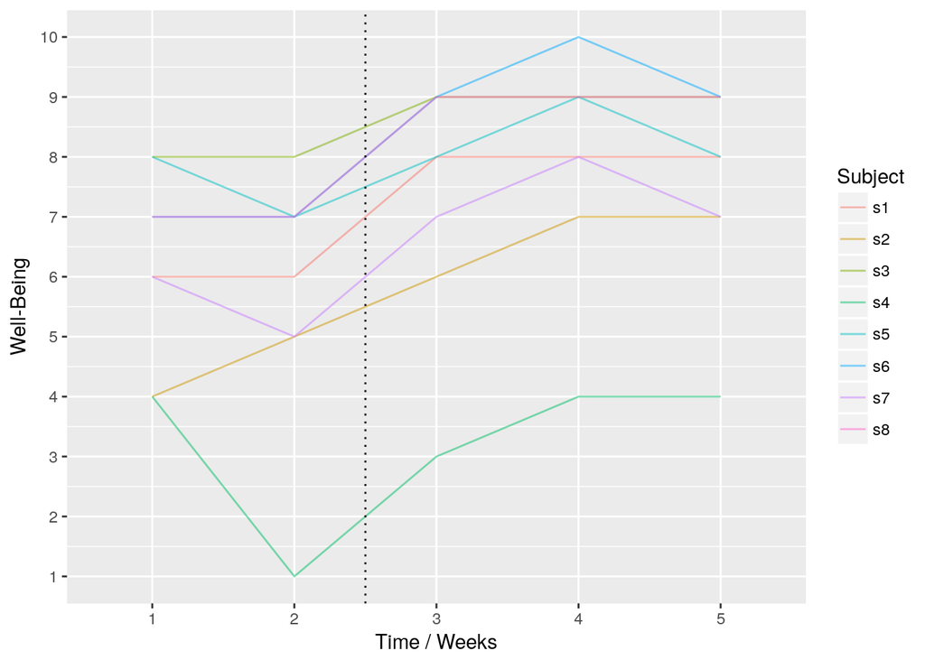

```r
ggplot(intervention, aes(x=time, y=well.being, group=sub, col=sub)) + geom_line(alpha=0.5) + scale_y_continuous(breaks=1:10) + labs(x="Time / Weeks", y="Well-Being", col="Subject") + geom_vline(xintercept=2.5, lty=3)
```

The `aov()` function is used for repeated measures data. Note the extra `Error(sub/time)` term, which means that time is varying within each subject—that each subject is measured at each time

The code `contrasts(intervention$time) <- contr.sum` does something technical. Because there is no natural time point to call out reference level, we are using *effects coding* (also called *sum to zero contrasts*). This makes sense whenever there is no natural reference level

```r
#contrasts(intervention$time) <- contr.treatment # The default contrast, where each level is contrasted with the first
contrasts(intervention$time) <- contr.sum # Each level is contrasted with the grand mean
m.well.being.by.time <- aov(well.being~time + Error(sub/time), data=intervention)
summary(m.well.being.by.time)
```

```
##
## Error: sub
##           Df Sum Sq Mean Sq F value Pr(>F)
## Residuals  7  115.2   16.46
##
## Error: sub:time
##           Df Sum Sq Mean Sq F value   Pr(>F)
## time       4  29.25   7.312   21.44 3.46e-08 ***
## Residuals 28   9.55   0.341
## ---
## Signif. codes:  0 '***' 0.001 '**' 0.01 '*' 0.05 '.' 0.1 ' ' 1
```

We write: “The effect of time is significant, $F(4,28)=21.4$, $p<.0001$”

## Contrasts on the correct repeated-measures ANOVA

```r
(  m.well.being.by.time.emm <- emmeans(m.well.being.by.time, ~time)  )
```

```
##  time emmean        SE   df lower.CL upper.CL
##  1     6.250 0.6674846 8.19 4.717118 7.782882
##  2     5.750 0.6674846 8.19 4.217118 7.282882
##  3     7.375 0.6674846 8.19 5.842118 8.907882
##  4     8.000 0.6674846 8.19 6.467118 9.532882
##  5     7.625 0.6674846 8.19 6.092118 9.157882
##
## Confidence level used: 0.95
```

```r
(  contrasts <- data.frame(after.minus.before=c(-1/2, -1/2, 1/3, 1/3, 1/3), t3.minus.t2=c(0, -1, 1, 0, 0))  )
```

```
##   after.minus.before t3.minus.t2
## 1         -0.5000000           0
## 2         -0.5000000          -1
## 3          0.3333333           1
## 4          0.3333333           0
## 5          0.3333333           0
```

```r
confint(contrast(m.well.being.by.time.emm, contrasts))
```

```
##  contrast           estimate        SE df lower.CL upper.CL
##  after.minus.before 1.666667 0.1884895 28 1.280564 2.052770
##  t3.minus.t2        1.625000 0.2920066 28 1.026852 2.223148
##
## Confidence level used: 0.95
```

“Well-being is 1.7 points higher 95% CI[1.3–2.1] after the intervention”

## Adjusted well-being

Averaging over weeks, some employees just have higher well-being than others. These individual differences are hiding the effect of our intervention

```r
(  mean.well.being <- intervention %>% group_by(sub) %>% summarise(mean.well.being=mean(well.being))  )
```

```
## # A tibble: 8 x 2
##   sub   mean.well.being
##   <chr>           <dbl>
## 1 s1               7.20
## 2 s2               5.80
## 3 s3               8.60
## 4 s4               3.20
## 5 s5               8.00
## 6 s6               8.40
## 7 s7               6.60
## 8 s8               8.20
```

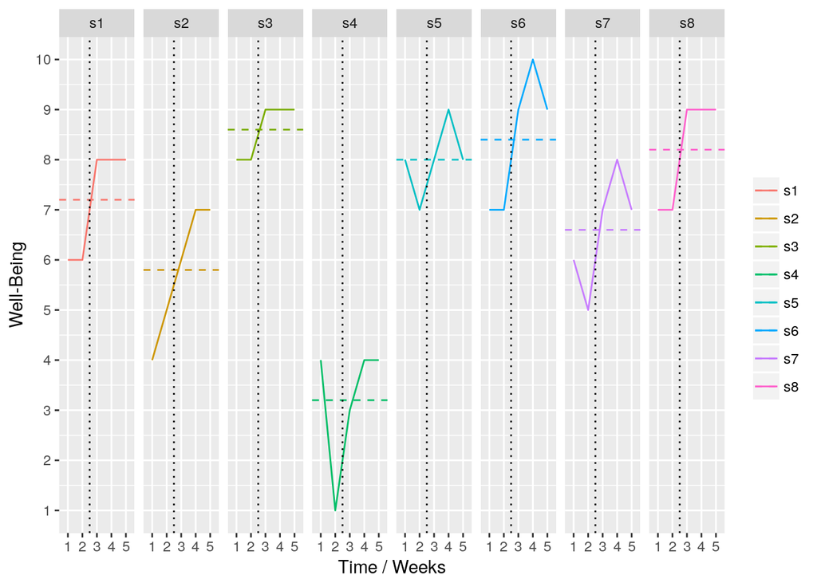

```r
ggplot(intervention, aes(x=time, y=well.being, group=sub, col=sub)) + geom_line() + facet_grid(.~sub) + geom_hline(data=mean.well.being, aes(yintercept=mean.well.being, col=sub), lty=2) + geom_vline(xintercept=2.5, lty=3) + labs(x="Time / Weeks", y="Well-Being", col=NULL) + scale_y_continuous(breaks=1:10)
```

Let’s adjust each person’s well-being score by subtracting their own personal mean

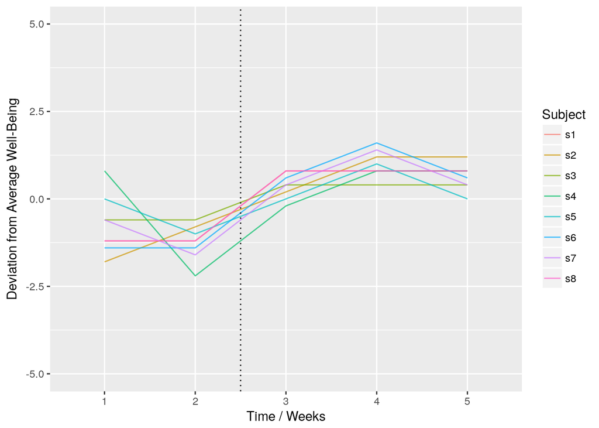

```r
intervention <- merge(intervention, mean.well.being)
intervention <- intervention %>% mutate(adjusted.well.being=well.being-mean.well.being)

ggplot(intervention, aes(x=time, y=adjusted.well.being, group=sub, col=sub)) + geom_line(alpha=0.7) + labs(x="Time / Weeks", y="Deviation from Average Well-Being", col="Subject") + geom_vline(xintercept=2.5, lty=3) + ylim(-5,5)
```

## Sources of variability

In the repeated-measures ANOVA all the variability due to subject differences is removed when thinking about the effect of time.

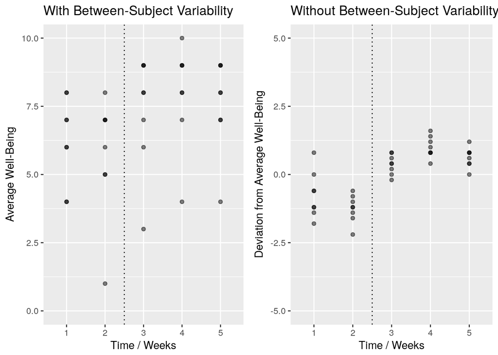

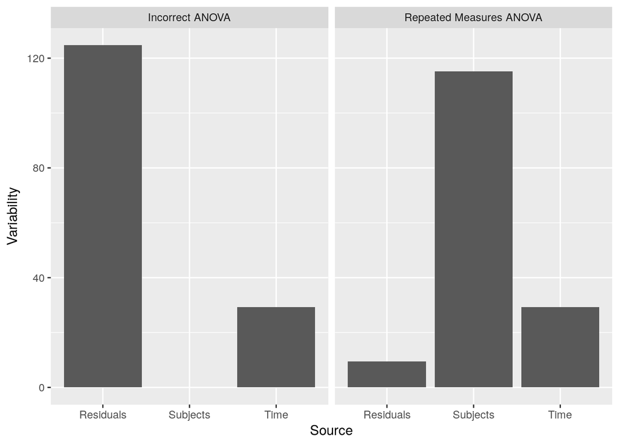

## Paired-samples $t$-test

Let’s compare before vs after with a paired samples $t$-test. This is nearly the same as the before–after contrast

```r
intervention <- intervention %>% mutate(timing=ifelse(time %in% 1:2, "Before", "After"))
(  intervention.timing <- intervention %>% group_by(sub, timing) %>% summarise(well.being=mean(well.being))  )
```

```
## # A tibble: 16 x 3
## # Groups:   sub [?]
##    sub   timing well.being
##    <chr> <chr>       <dbl>
##  1 s1    After        8.00
##  2 s1    Before       6.00
##  3 s2    After        6.67
##  4 s2    Before       4.50
##  5 s3    After        9.00
##  6 s3    Before       8.00
##  7 s4    After        3.67
##  8 s4    Before       2.50
##  9 s5    After        8.33
## 10 s5    Before       7.50
## 11 s6    After        9.33
## 12 s6    Before       7.00
## 13 s7    After        7.33
## 14 s7    Before       5.50
## 15 s8    After        9.00
## 16 s8    Before       7.00
```

```r
(  intervention.timing.wide <- intervention.timing %>% spread(timing, well.being)  )
```

```
## # A tibble: 8 x 3
## # Groups:   sub [8]
##   sub   After Before
##   <chr> <dbl>  <dbl>
## 1 s1     8.00   6.00
## 2 s2     6.67   4.50
## 3 s3     9.00   8.00
## 4 s4     3.67   2.50
## 5 s5     8.33   7.50
## 6 s6     9.33   7.00
## 7 s7     7.33   5.50
## 8 s8     9.00   7.00
```

```r
t.test(intervention.timing.wide$Before, intervention.timing.wide$After, paired=TRUE)
```

```
##
##  Paired t-test
##
## data:  intervention.timing.wide$Before and intervention.timing.wide$After
## t = -8.165, df = 7, p-value = 7.999e-05
## alternative hypothesis: true difference in means is not equal to 0
## 95 percent confidence interval:
##  -2.149344 -1.183990
## sample estimates:
## mean of the differences
##               -1.666667
```

# Mixed ANOVA

*Always* plot repeated measures data *for each participant*

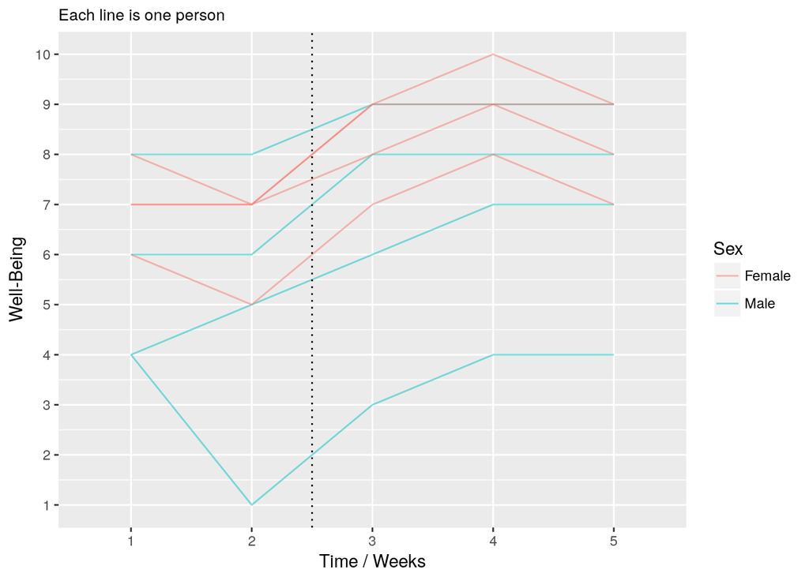

```r
ggplot(intervention, aes(x=time, y=well.being, group=sub, col=sex)) + geom_line(alpha=0.5) + scale_y_continuous(breaks=1:10) + labs(x="Time / Weeks", y="Well-Being", col="Sex", subtitle="Each line is one person") + geom_vline(xintercept=2.5, lty=3)
```

```r
m.well.being.by.time.sex <- aov(well.being~time*sex + Error(sub/time), data=intervention)
summary(m.well.being.by.time.sex)
```

```
##
## Error: sub
##           Df Sum Sq Mean Sq F value Pr(>F)
## sex        1   25.6   25.60   1.714  0.238
## Residuals  6   89.6   14.93
##
## Error: sub:time
##           Df Sum Sq Mean Sq F value   Pr(>F)
## time       4  29.25   7.312  19.719 2.65e-07 ***
## time:sex   4   0.65   0.163   0.438     0.78
## Residuals 24   8.90   0.371
## ---
## Signif. codes:  0 '***' 0.001 '**' 0.01 '*' 0.05 '.' 0.1 ' ' 1
```

## Contrasts on the correct repeated-measures ANOVA

```r
(  m.well.being.by.time.sex.emm <- emmeans(m.well.being.by.time.sex, ~time + sex)  )
```

```
##  time sex    emmean        SE   df  lower.CL upper.CL
##  1    Female   6.20 0.6689544 8.54 4.6741019 7.725898
##  2    Female   5.70 0.6689544 8.54 4.1741019 7.225898
##  3    Female   7.45 0.6689544 8.54 5.9241019 8.975898
##  4    Female   8.20 0.6689544 8.54 6.6741019 9.725898
##  5    Female   7.45 0.6689544 8.54 5.9241019 8.975898
##  1    Male     4.70 1.3931379 6.48 1.3518211 8.048179
##  2    Male     4.20 1.3931379 6.48 0.8518211 7.548179
##  3    Male     5.70 1.3931379 6.48 2.3518211 9.048179
##  4    Male     6.20 1.3931379 6.48 2.8518211 9.548179
##  5    Male     6.20 1.3931379 6.48 2.8518211 9.548179
##
## Confidence level used: 0.95
```

```r
(  interaction.contrast <- data.frame(timing.by.sex.interaction=c(-1/2, -1/2, 1/3, 1/3, 1/3, 1/2, 1/2, -1/3, -1/3, -1/3))  )
```

```
##    timing.by.sex.interaction
## 1                 -0.5000000
## 2                 -0.5000000
## 3                  0.3333333
## 4                  0.3333333
## 5                  0.3333333
## 6                  0.5000000
## 7                  0.5000000
## 8                 -0.3333333
## 9                 -0.3333333
## 10                -0.3333333
```

```r
confint(contrast(m.well.being.by.time.sex.emm, interaction.contrast))
```

```
##  contrast                   estimate        SE df   lower.CL  upper.CL
##  timing.by.sex.interaction 0.1666667 0.3930825 24 -0.6446158 0.9779492
##
## Confidence level used: 0.95
```

“The improvement in well-being for men is 0.17 95% CI[-0.64–0.98] smaller than the improvement for women”

# References

Howell, D. C. (2017) *Fundamental statistics for the behavioral sciences*. 9th edn. Belmont, CA: Duxbury Press.